# Markdown_template_2

Patrick Ericx

July 5, 2016

## Loading and preprocessing the data

Show any code that is needed to  
1.Load the data (i.e. read.csv())

```r
sourcefile <- "activity.csv"
sourcedata <- read.csv(sourcefile)
```

2.Process/transform the data (if necessary) into a format suitable for your analysis  
Nothing special required.

## What is mean total number of steps taken per day?

For this part of the assignment, you can ignore the missing values in the dataset.

```r
completedata <- na.omit(sourcedata)
```

1.Calculate the total number of steps taken per day

```r
workdata <- completedata[1:2]
stepsPerDay <- aggregate(steps ~ date, workdata, sum)
stepsPerDay
```

```
##          date steps
## 1  2012-10-02   126
## 2  2012-10-03 11352
## 3  2012-10-04 12116
## 4  2012-10-05 13294
## 5  2012-10-06 15420
## 6  2012-10-07 11015
## 7  2012-10-09 12811
## 8  2012-10-10  9900
## 9  2012-10-11 10304
## 10 2012-10-12 17382
## 11 2012-10-13 12426
## 12 2012-10-14 15098
## 13 2012-10-15 10139
## 14 2012-10-16 15084
```

[output cut: 39 more lines]

2.Make a histogram of the total number of steps taken each day

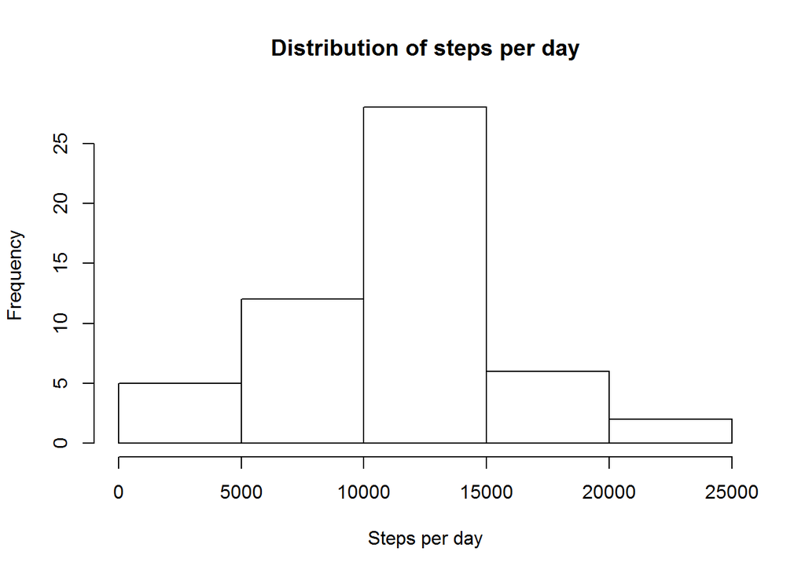

```r
hist(stepsPerDay$steps, main="Distribution of steps per day", xlab="Steps per day")
```

3.Calculate and report the mean and median of the total number of steps taken per day

```r
mean(stepsPerDay[,2])
```

```
## [1] 10766.19
```

```r
median(stepsPerDay[,2])
```

```
## [1] 10765
```

Those values fall in the highest block in the histogram. This confirms that our calculation makes sense.

## What is the average daily activity pattern?

1.Make a time series plot (i.e. type = “l”) of the 5-minute interval (x-axis) and the average number of steps taken, averaged across all days (y-axis).

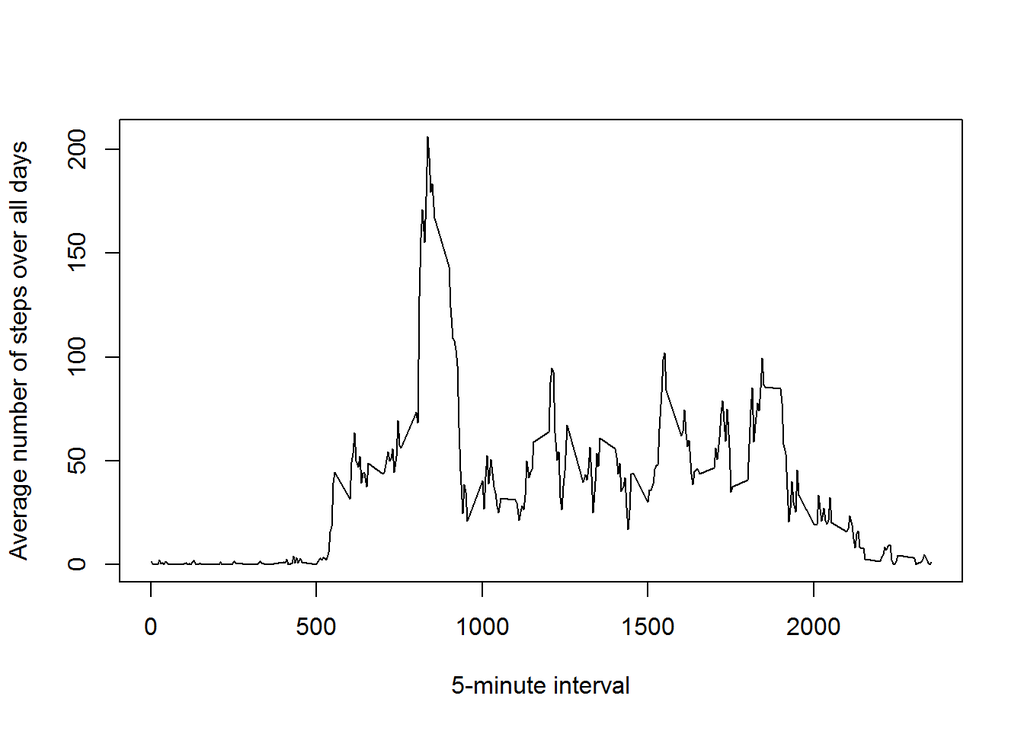

```r
fiveMinuteAverage <- aggregate(steps ~ interval, completedata, mean)
plot(fiveMinuteAverage$interval, fiveMinuteAverage$steps, type="l", xlab="5-minute interval", ylab="Average number of steps over all days")
```

2.Which 5-minute interval, on average across all the days in the dataset, contains the maximum number of steps?

```r
fiveMinuteAverage[fiveMinuteAverage$steps == max(fiveMinuteAverage$steps),]
```

```
##     interval    steps
## 104      835 206.1698
```

This is again confirmed by the graph.

## Imputing missing values

1.Calculate and report the total number of missing values in the dataset (i.e. the total number of rows with NAs)

```r
sum(is.na(sourcedata$steps))
```

```
## [1] 2304
```

```r
sum(is.na(sourcedata$date))
```

```
## [1] 0
```

```r
sum(is.na(sourcedata$interval))
```

```
## [1] 0
```

2.Devise a strategy for filling in all of the missing values in the dataset. The strategy does not need to be sophisticated. For example, you could use the mean/median for that day, or the mean for that 5-minute interval, etc.  
We fill the NA values with the mean of the corresponding 5-minute interval. 3.Create a new dataset that is equal to the original dataset but with the missing data filled in.  
[Stackoverflow: R replacing NA values with dplyr](http://stackoverflow.com/questions/26336122/r-replacing-na-values-by-mean-of-hour-with-dplyr)

```r
#install.packages("dplyr")
library(dplyr)
 imputateddata <- sourcedata %>%
                  group_by(interval) %>%
                  mutate(steps = replace(steps, is.na(steps),mean(steps, na.rm=TRUE)))
```

4.Make a histogram of the total number of steps taken each day and Calculate and report the mean and median total number of steps taken per day. Do these values differ from the estimates from the first part of the assignment? What is the impact of imputing missing data on the estimates of the total daily number of steps?

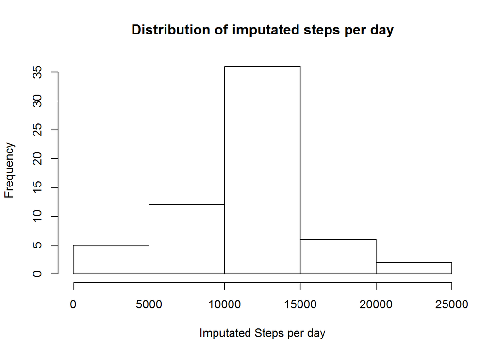

```r
stepsPerDayImputated <- aggregate(steps ~ date, imputateddata, sum)
hist(stepsPerDayImputated$steps, main="Distribution of imputated steps per day", xlab="Imputated Steps per day")
```

```r
mean(stepsPerDayImputated[,2])
```

```
## [1] 10766.19
```

```r
median(stepsPerDayImputated[,2])
```

```
## [1] 10766.19
```

What is the impact of imputing missing data on the estimates of the total daily number of steps?  
Total number of daily steps increases, I think.

## Are there differences in activity patterns between weekdays and weekends?

Use the dataset with the filled-in missing values for this part.  
1.Create a new factor variable in the dataset with two levels - “weekday” and “weekend” indicating whether a given date is a weekday or weekend day.

```r
imputatedIntervals <- imputateddata
imputatedIntervals$date <- as.Date(imputateddata$date)
#create a vector of weekdays
weekdaysList <- c("Monday", "Tuesday", "Wednesday", "Thursday", "Friday")
#Use %in% and weekdaysList to create a logical vector
#convert to factor and specify the labels
imputatedIntervals$weekDay <- factor((weekdays(imputatedIntervals$date) %in% weekdaysList),
         levels=c(TRUE, FALSE), labels=c("weekday", "weekend") )
```

2.Make a panel plot containing a time series plot (i.e. type = “l”) of the 5-minute interval (x-axis) and the average number of steps taken, averaged across all weekday days or weekend days (y-axis). See the README file in the GitHub repository to see an example of what this plot should look like using simulated data.

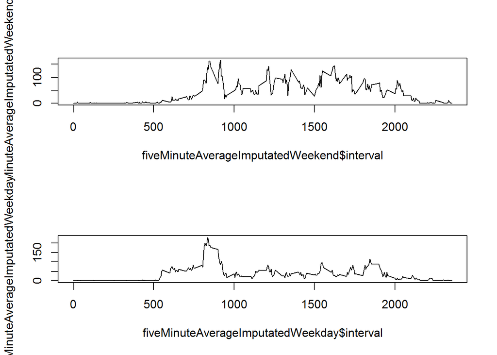

```r
fiveMinuteAverageImputatedWeekend <- aggregate(steps ~ interval, imputatedIntervals[imputatedIntervals$weekDay == "weekend", ], mean)
fiveMinuteAverageImputatedWeekday <- aggregate(steps ~ interval, imputatedIntervals[imputatedIntervals$weekDay == "weekday", ], mean)
par(mfrow=c(2,1))
plot(fiveMinuteAverageImputatedWeekend$interval, fiveMinuteAverageImputatedWeekend$steps, type="l")
plot(fiveMinuteAverageImputatedWeekday$interval, fiveMinuteAverageImputatedWeekday$steps, type="l")
```